# Assignment 3

Gus Lipkin ~ glipkin6737@floridapoly.edu

# Problem 1 (Q6)

> Suppose we collect data for a group of students in a statistics class with variables $X_1$ = hours studied, $X_2$ = undergrad GPA, and $Y$ = receive an A. We fit a logistic regression and produce estimated coefficient, $βˆ0 = −6$, $βˆ1 = 0.05$, $βˆ2 = 1$.

## 6b

> How many hours would the student in part (a) need to study to have a $50\%$ chance of getting an A in the class?

(This is unhealthy)

# Problem 2 (Q9)

> This problem has to do with *odds*.

## 9a

> On average, what fraction of people with an odds of 0.37 of defaulting on their credit card payment will in fact default?

$$=\frac{.37}{1+.37}\\
=\frac{.37}{1.37}\\
=.2700\\$$

## 9b

> Suppose that an individual has a $16\%$ chance of defaulting on her credit card payment. What are the odds that she will de- fault?

$$.16=\frac{x}{1+x}\\
.16+.16x=x\\
.16=.84x\\
x=.1905$$

# Problem 3 (Q13)

> This question should be answered using the `Weekly` data set, which is part of the `ISLR2` package. This data is similar in nature to the `Smarket` data from this chapter’s lab, except that it contains 1,089 weekly returns for 21 years, from the beginning of 1990 to the end of 2010.

```r
library(tidyverse)
library(data.table)

dt <- data.table(ISLR2::Weekly)
head(dt)
```

| Year | Lag1 | Lag2 | Lag3 | Lag4 | Lag5 | Volume | Today | Direction |
| --- | --- | --- | --- | --- | --- | --- | --- | --- |
| 1990 | 0.816 | 1.572 | -3.936 | -0.229 | -3.484 | 0.1549760 | -0.270 | Down |
| 1990 | -0.270 | 0.816 | 1.572 | -3.936 | -0.229 | 0.1485740 | -2.576 | Down |
| 1990 | -2.576 | -0.270 | 0.816 | 1.572 | -3.936 | 0.1598375 | 3.514 | Up |
| 1990 | 3.514 | -2.576 | -0.270 | 0.816 | 1.572 | 0.1616300 | 0.712 | Up |
| 1990 | 0.712 | 3.514 | -2.576 | -0.270 | 0.816 | 0.1537280 | 1.178 | Up |
| 1990 | 1.178 | 0.712 | 3.514 | -2.576 | -0.270 | 0.1544440 | -1.372 | Down |

## 13a

> Produce some numerical and graphical summaries of the `Weekly` data. Do there appear to be any patterns?

```r
summary(dt)
```

```
      Year           Lag1               Lag2               Lag3               Lag4               Lag5              Volume            Today          Direction
 Min.   :1990   Min.   :-18.1950   Min.   :-18.1950   Min.   :-18.1950   Min.   :-18.1950   Min.   :-18.1950   Min.   :0.08747   Min.   :-18.1950   Down:484
 1st Qu.:1995   1st Qu.: -1.1540   1st Qu.: -1.1540   1st Qu.: -1.1580   1st Qu.: -1.1580   1st Qu.: -1.1660   1st Qu.:0.33202   1st Qu.: -1.1540   Up  :605
 Median :2000   Median :  0.2410   Median :  0.2410   Median :  0.2410   Median :  0.2380   Median :  0.2340   Median :1.00268   Median :  0.2410
 Mean   :2000   Mean   :  0.1506   Mean   :  0.1511   Mean   :  0.1472   Mean   :  0.1458   Mean   :  0.1399   Mean   :1.57462   Mean   :  0.1499
 3rd Qu.:2005   3rd Qu.:  1.4050   3rd Qu.:  1.4090   3rd Qu.:  1.4090   3rd Qu.:  1.4090   3rd Qu.:  1.4050   3rd Qu.:2.05373   3rd Qu.:  1.4050
 Max.   :2010   Max.   : 12.0260   Max.   : 12.0260   Max.   : 12.0260   Max.   : 12.0260   Max.   : 12.0260   Max.   :9.32821   Max.   : 12.0260
```

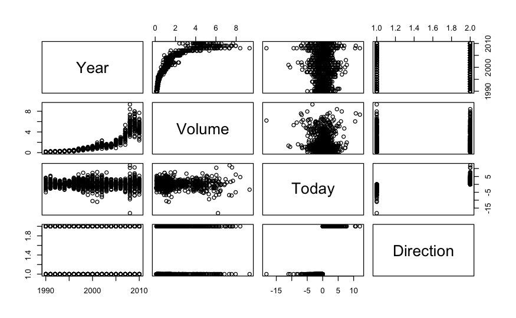

```r
pairs(dt[, .(Year, Volume, Today, Direction)])
```

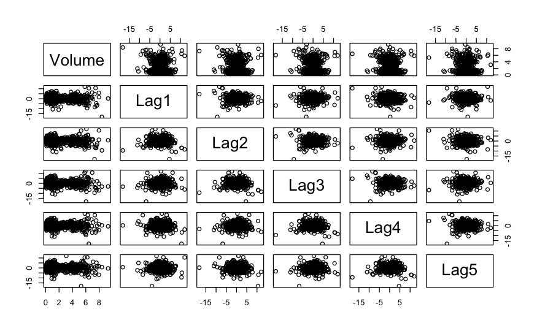

```r
pairs(dt[, .(Volume, Lag1, Lag2, Lag3, Lag4, Lag5)])
```

Volume goes up. Daily change is generally small. Lags look consistent to each other.

## 13b

> Use the full data set to perform a logistic regression with `Direction` as the response and the five lag variables plus `Volume` as predictors. Use the summary function to print the results. Do any of the predictors appear to be statistically significant? If so, which ones?

```r
dt$Direction <- ifelse(dt$Direction == "Up", 1, 0)
lm <- glm(Direction ~ . - Year - Today, data = dt, family = "binomial")
lm
```

```
Call:  glm(formula = Direction ~ . - Year - Today, family = "binomial",
    data = dt)

Coefficients:
(Intercept)         Lag1         Lag2         Lag3         Lag4         Lag5       Volume
    0.26686     -0.04127      0.05844     -0.01606     -0.02779     -0.01447     -0.02274

Degrees of Freedom: 1088 Total (i.e. Null);  1082 Residual
Null Deviance:      1496
Residual Deviance: 1486     AIC: 1500
```

```r
summary(lm)
```

```
Call:
glm(formula = Direction ~ . - Year - Today, family = "binomial",
    data = dt)

Deviance Residuals:
    Min       1Q   Median       3Q      Max
-1.6949  -1.2565   0.9913   1.0849   1.4579

Coefficients:
            Estimate Std. Error z value Pr(>|z|)
(Intercept)  0.26686    0.08593   3.106   0.0019 **
Lag1        -0.04127    0.02641  -1.563   0.1181
Lag2         0.05844    0.02686   2.175   0.0296 *
Lag3        -0.01606    0.02666  -0.602   0.5469
Lag4        -0.02779    0.02646  -1.050   0.2937
Lag5        -0.01447    0.02638  -0.549   0.5833
Volume      -0.02274    0.03690  -0.616   0.5377
---
Signif. codes:  0 ‘***’ 0.001 ‘**’ 0.01 ‘*’ 0.05 ‘.’ 0.1 ‘ ’ 1

(Dispersion parameter for binomial family taken to be 1)

    Null deviance: 1496.2  on 1088  degrees of freedom
Residual deviance: 1486.4  on 1082  degrees of freedom
AIC: 1500.4

Number of Fisher Scoring iterations: 4
```

Lag two appears the most statistically significant.

## 13c

> Compute the confusion matrix and overall fraction of correct predictions. Explain what the confusion matrix is telling you about the types of mistakes made by logistic regression.

```r
pred <- round(predict(lm, dt, type = "response"))
table(pred, dt$Direction)
```

```
pred   0   1
   0  54  48
   1 430 557
```

```r
mean(pred == dt$Direction)
```

```
[1] 0.5610652
```

## 13d

> Now fit the logistic regression model using a training data period from 1990 to 2008, with `Lag2` as the only predictor. Compute the confusion matrix and the overall fraction of correct predictions for the held out data (that is, the data from 2009 and 2010).

```r
train <- dt[Year %in% range(1990, 2008)]
test <- dt[!(Year %in% range(1990, 2008))]
lm <- glm(Direction ~ Lag2, data = train, family = "binomial")
lm
```

```
Call:  glm(formula = Direction ~ Lag2, family = "binomial", data = train)

Coefficients:
(Intercept)         Lag2
   -0.07308      0.07075

Degrees of Freedom: 98 Total (i.e. Null);  97 Residual
Null Deviance:      137
Residual Deviance: 135.5    AIC: 139.5
```

```r
summary(lm)
```

```
Call:
glm(formula = Direction ~ Lag2, family = "binomial", data = train)

Deviance Residuals:
    Min       1Q   Median       3Q      Max
-1.4715  -1.1456  -0.9534   1.1862   1.5025

Coefficients:
            Estimate Std. Error z value Pr(>|z|)
(Intercept) -0.07308    0.20389  -0.358    0.720
Lag2         0.07075    0.05902   1.199    0.231

(Dispersion parameter for binomial family taken to be 1)

    Null deviance: 136.99  on 98  degrees of freedom
Residual deviance: 135.46  on 97  degrees of freedom
AIC: 139.46

Number of Fisher Scoring iterations: 4
```

```r
pred <- round(predict(lm, test, type = "response"))
table(pred, test$Direction)
```

```
pred   0   1
   0 296 362
   1 136 196
```

```r
mean(pred == test$Direction)
```

```
[1] 0.4969697
```

# Problem 4 (Q14)

> In this problem, you will develop a model to predict whether a given car gets high or low gas mileage based on the `Auto` data set.

```r
dt <- data.table(ISLR2::Auto)
```

## 14a

> Create a binary variable, `mpg01`, that contains a 1 if `mpg` contains a value above its median, and a 0 if `mpg` contains a value below its median. You can compute the median using the `median()` function. Note you may find it helpful to use the `data.frame()` function to create a single data set containing both `mpg01` and the other `Auto` variables.

```r
dt$mpg01 <- ifelse(dt$mpg > median(dt$mpg), 1, 0)
```

## 14b

> Explore the data graphically in order to investigate the association between `mpg01` and the other features. Which of the other features seem most likely to be useful in predicting `mpg01`? Scatterplots and boxplots may be useful tools to answer this question. Describe your findings.

[output not shown]

[output cut: 38 more lines]

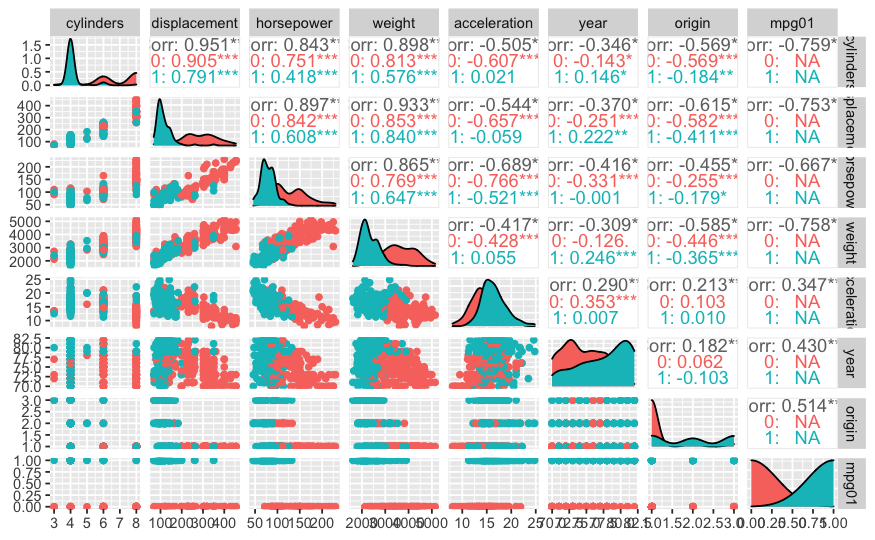

```r
GGally::ggpairs(dt[, !c("name", "mpg")], aes(color = as.factor(mpg01)))
```

I’ve definitely done this before already but whatever. There is a clear difference between cars that are above and below the median. The biggest differences are in the `displacement`, `horespower`, and `weight` categories.

## 14c

> Split the data into a training set and a test set.

```r
set.seed(2022)
rowPicker <- sample(c(TRUE,FALSE), nrow(dt), TRUE)

train <- dt[rowPicker]
test <- dt[!rowPicker]
```

## 14f

> Perform logistic regression on the training data in order to predict `mpg01` using the variables that seemed most associated with `mpg01` in (b). What is the test error of the model obtained?

```r
train <- train[, !c("mpg", "name")]
lm <- glm(mpg01 ~ ., data = train, family = "binomial")
lmSumm <- summary(lm)
coefs <- coef(lmSumm)[-1,4] <= .05

# This prunes the regression until only significant variables remain
while(length(coefs) != sum(coefs)) {
  form <- paste("mpg01 ~", paste(names(coefs[coefs]), "+", collapse = " "), collapse = " ")
  form <- substr(form, 1, nchar(form) - 2)
  form
  lm <- glm(formula = form, data = train, family = "binomial")
  lmSumm <- summary(lm)
  coefs <- coef(lmSumm)[-1,4] <= .05
}
lmSumm
```

```
Call:
glm(formula = form, family = "binomial", data = train)

Deviance Residuals:
     Min        1Q    Median        3Q       Max
-2.43160  -0.08817   0.01865   0.17382   2.51281

Coefficients:
              Estimate Std. Error z value Pr(>|z|)
(Intercept) -21.961020   7.110623  -3.088  0.00201 **
weight       -0.006389   0.001039  -6.152 7.67e-10 ***
year          0.526490   0.114995   4.578 4.69e-06 ***
---
Signif. codes:  0 ‘***’ 0.001 ‘**’ 0.01 ‘*’ 0.05 ‘.’ 0.1 ‘ ’ 1

(Dispersion parameter for binomial family taken to be 1)

    Null deviance: 284.146  on 204  degrees of freedom
Residual deviance:  73.825  on 202  degrees of freedom
AIC: 79.825

Number of Fisher Scoring iterations: 7
```

```r
pred <- round(predict(lm, test, type = "response"))
table(pred, test$mpg01)
```

```
pred  0  1
   0 82  8
   1 13 84
```

```r
mean(pred != test$mpg01)
```

```
[1] 0.1122995
```

The test error is $.1122$.

# Problem 5

> Use the `Boston` data set to fit a logistic regression model to predict whether a given census tract has a crime rate above or below the median using various predictors. You will have to create the response variable yourself using the variables from the data set. Describe your findings.

```r
dt <- data.table(ISLR2::Boston)
dt$danger <- ifelse(dt$crim > median(dt$crim), 1, 0)
head(dt)
```

| crim | zn | indus | chas | nox | rm | age | dis | rad | tax | ptratio | lstat | medv | danger |
| --- | --- | --- | --- | --- | --- | --- | --- | --- | --- | --- | --- | --- | --- |
| 0.00632 | 18 | 2.31 | 0 | 0.538 | 6.575 | 65.2 | 4.0900 | 1 | 296 | 15.3 | 4.98 | 24.0 | 0 |
| 0.02731 | 0 | 7.07 | 0 | 0.469 | 6.421 | 78.9 | 4.9671 | 2 | 242 | 17.8 | 9.14 | 21.6 | 0 |
| 0.02729 | 0 | 7.07 | 0 | 0.469 | 7.185 | 61.1 | 4.9671 | 2 | 242 | 17.8 | 4.03 | 34.7 | 0 |
| 0.03237 | 0 | 2.18 | 0 | 0.458 | 6.998 | 45.8 | 6.0622 | 3 | 222 | 18.7 | 2.94 | 33.4 | 0 |
| 0.06905 | 0 | 2.18 | 0 | 0.458 | 7.147 | 54.2 | 6.0622 | 3 | 222 | 18.7 | 5.33 | 36.2 | 0 |
| 0.02985 | 0 | 2.18 | 0 | 0.458 | 6.430 | 58.7 | 6.0622 | 3 | 222 | 18.7 | 5.21 | 28.7 | 0 |

```r
set.seed(2022)
rowPicker <- sample(c(TRUE,FALSE), nrow(dt), TRUE, prob = c(.8, .2))

train <- dt[rowPicker, !c("crim")]
test <- dt[!rowPicker]

# train <- train[, !c("mpg", "name")]
lm <- glm(danger ~ ., data = train, family = "binomial")
lmSumm <- summary(lm)
coefs <- coef(lmSumm)[-1,4] <= .05

# This prunes the regression until only significant variables remain
while(length(coefs) != sum(coefs)) {
  form <- paste("danger ~", paste(names(coefs[coefs]), "+", collapse = " "), collapse = " ")
  form <- substr(form, 1, nchar(form) - 2)
  form
  lm <- glm(formula = form, data = train, family = "binomial")
  lmSumm <- summary(lm)
  coefs <- coef(lmSumm)[-1,4] <= .05
}
lmSumm
```

```
Call:
glm(formula = form, family = "binomial", data = train)

Deviance Residuals:
     Min        1Q    Median        3Q       Max
-2.03168  -0.28320  -0.00401   0.00248   2.83915

Coefficients:
              Estimate Std. Error z value Pr(>|z|)
(Intercept) -17.394642   2.487808  -6.992 2.71e-12 ***
zn           -0.070081   0.025817  -2.715  0.00664 **
nox          31.239887   4.729242   6.606 3.96e-11 ***
rad           0.731924   0.141459   5.174 2.29e-07 ***
tax          -0.008553   0.002713  -3.153  0.00162 **
---
Signif. codes:  0 ‘***’ 0.001 ‘**’ 0.01 ‘*’ 0.05 ‘.’ 0.1 ‘ ’ 1

(Dispersion parameter for binomial family taken to be 1)

    Null deviance: 543.17  on 391  degrees of freedom
Residual deviance: 193.64  on 387  degrees of freedom
AIC: 203.64

Number of Fisher Scoring iterations: 8
```

```r
pred <- round(predict(lm, test, type = "response"))
table(pred, test$danger)
```

```
pred  0  1
   0 42  5
   1 10 57
```

```r
mean(pred == test$danger)
```

```
[1] 0.8684211
```

This model is correct $86.84\%$ of the time and is based on the `zn`, `nox`, `rad`, and `tax` variables. If I change the training dataset to be a different sample, then the best regression changes as well.

# Problem 6

> You are given 151 observations of a travel survey collected in State College Pennsylvania (please see Problem6_Assignment3.xlsx). All the households in the sample are making the morning commute to work. They are all departing from the same origin (a large residential complex in the suburbs) and going to work in the Central Business District. They have the choice of two alternate routes: 1) a two-lane rural road (speed limit = 35mph, 1 lane each direction) and 2) a limited access four-lane freeway (speed limit = 55mph, 2 lanes each direction). Please estimate a model of route choice (i.e., the likelihood of an individual traveler taking one of the two routes) including all the appropriate predictors. Describe your findings i.e., include the coefficient estimates and odds ratios and justify the sign of your variables. The dataset includes the following variables:

```r
library(data.table)
library(tidyverse)
dt <- fread("Problem6_Assignment3.csv")
head(dt)
```

| travelTime | route | flowRate | lights | distance | seatBelts | passengers | age | sex | maritalStatus | children | income | modelYear | origin |
| --- | --- | --- | --- | --- | --- | --- | --- | --- | --- | --- | --- | --- | --- |
| 14 | 1 | 600 | 7 | 44 | 1 | 0 | 5 | 1 | 0 | 3 | 5 | 78 | 0 |
| 13 | 1 | 400 | 7 | 44 | 0 | 0 | 1 | 0 | 1 | 0 | 1 | 85 | 1 |
| 11 | 1 | 540 | 7 | 44 | 1 | 0 | 2 | 1 | 0 | 0 | 2 | 81 | 0 |
| 12 | 1 | 540 | 7 | 44 | 1 | 0 | 5 | 0 | 1 | 0 | 4 | 83 | 1 |
| 9 | 1 | 370 | 7 | 44 | 1 | 0 | 5 | 0 | 1 | 0 | 4 | 83 | 1 |
| 10 | 1 | 350 | 7 | 44 | 1 | 0 | 3 | 1 | 1 | 0 | 3 | 81 | 0 |

```r
dt$route <- ifelse(dt$route == 1, 1, 0)
```

[output not shown]

[output cut: 9 more lines]

```r
lm <- glm(route ~ flowRate, data = dt[!rowPicker], family = "binomial")
lm
```

```
Call:  glm(formula = route ~ flowRate, family = "binomial", data = dt[!rowPicker])

Coefficients:
(Intercept)     flowRate
  -12.85822      0.04327

Degrees of Freedom: 46 Total (i.e. Null);  45 Residual
Null Deviance:      42.89
Residual Deviance: 8.386    AIC: 12.39
```

```r
summ <- summary(lm)
summ
```

```
Call:
glm(formula = route ~ flowRate, family = "binomial", data = dt[!rowPicker])

Deviance Residuals:
     Min        1Q    Median        3Q       Max
-2.44458   0.00044   0.00739   0.21017   0.72393

Coefficients:
             Estimate Std. Error z value Pr(>|z|)
(Intercept) -12.85822    7.31935  -1.757   0.0790 .
flowRate      0.04327    0.02125   2.037   0.0417 *
---
Signif. codes:  0 ‘***’ 0.001 ‘**’ 0.01 ‘*’ 0.05 ‘.’ 0.1 ‘ ’ 1

(Dispersion parameter for binomial family taken to be 1)

    Null deviance: 42.8850  on 46  degrees of freedom
Residual deviance:  8.3857  on 45  degrees of freedom
AIC: 12.386

Number of Fisher Scoring iterations: 9
```

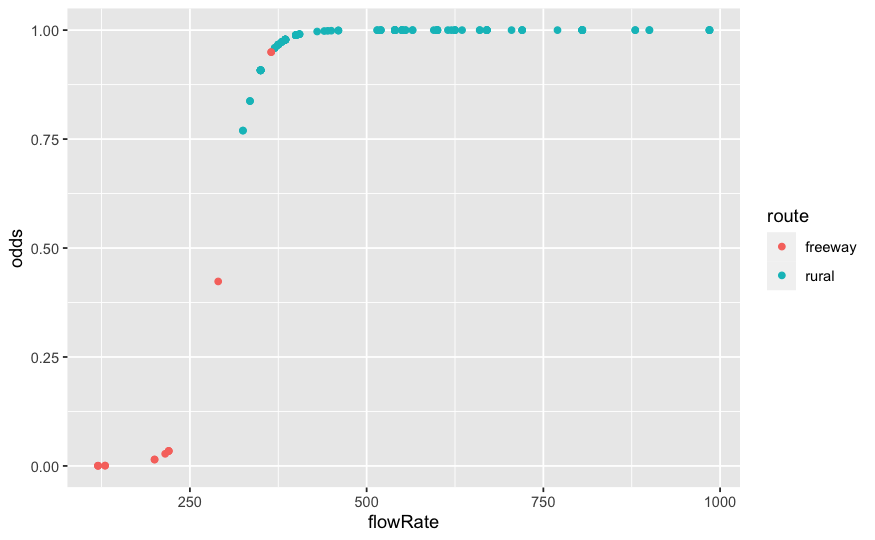

```r
coef <- coef(lm)

df <- data.frame("route" = as.factor(ifelse(dt$route == 1, "rural", "freeway")),
                 "flowRate" = dt$flowRate,
                 "odds" = exp(coef[1] + (dt$flowRate)*coef[2]) /
                   (1 + exp(coef[1] + (dt$flowRate)*coef[2]))
)
df %>%
  ggplot() +
  geom_point(aes(x = flowRate, y = odds, color = route))
```